# Math 425 Computation Linear Algebra

## HW2, Part A

### Brent A. Thorne

brentathorne@gmail.com

##### Linear independence, Span, and Vector spaces.

```python
# environment setup
import numpy as np # nice arrays and other stuff

#from sympy import * # import the entire namespace of sympy at root, NOT the best of practices
import sympy as sym # make is clear which lib I'm using for what
from sympy.matrices import Matrix # Include this in case we want some pretty matrices
from sympy.solvers.solveset import linsolve

from math import e, pi
from IPython.display import display, Math, Latex # used to display formatted results
sym.init_printing()  # initialize pretty printing
```

### 1. List five vectors in $span \{v_1 , v_2 \}$. For each vector, show the weights on $v_1, v_2$ used to generate the vector and list the three entries of the vector. Do not make a sketch.

$v_1 = \begin{bmatrix} 3\\ 0\\ 2\\ \end{bmatrix}, v_2 = \begin{bmatrix} -2\\ 0\\ 3\\ \end{bmatrix}$

```python
# our varibles
a = [-1, 0, 1, 2, 3]
b = [1, 0 , -1, -2, -3]

#our vectors
v_1 = Matrix([3, 0, 2])
v_2 = Matrix([-2, 0, 3])

display(Latex(f'Five vectors in the $span({sym.latex(v_1)},{sym.latex(v_2)})$ are:'))
[display(Math(f'({a[i]})v_1 + ({b[i]})v_2 = {sym.latex(a[i] * v_1 + b[i] * v_2)}' )) for i in range(len(a))]
display(Latex('Sweet!!! We have $\LaTeX$ formating to working. This will come in handy later.'))
```

Five vectors in the $span(\left[\begin{matrix}3\\0\\2\end{matrix}\right],\left[\begin{matrix}-2\\0\\3\end{matrix}\right])$ are:

$\displaystyle (-1)v_1 + (1)v_2 = \left[\begin{matrix}-5\\0\\1\end{matrix}\right]$

$\displaystyle (0)v_1 + (0)v_2 = \left[\begin{matrix}0\\0\\0\end{matrix}\right]$

$\displaystyle (1)v_1 + (-1)v_2 = \left[\begin{matrix}5\\0\\-1\end{matrix}\right]$

$\displaystyle (2)v_1 + (-2)v_2 = \left[\begin{matrix}10\\0\\-2\end{matrix}\right]$

$\displaystyle (3)v_1 + (-3)v_2 = \left[\begin{matrix}15\\0\\-3\end{matrix}\right]$

Sweet!!! We have $\LaTeX$ formating to working. This will come in handy later.

### 2. Decide whether the following sets of vectors are linearly independent or linearly dependent. Give reasons for your choices.

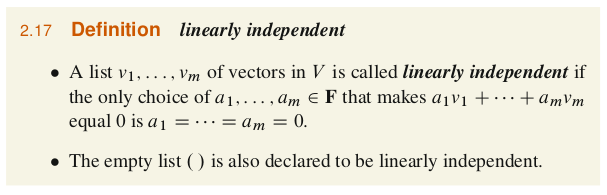

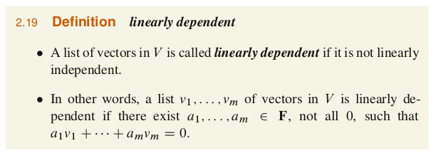

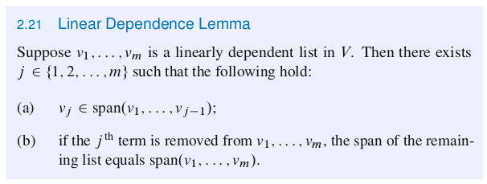

- Def and Lemma from 'Linear Algebra Done Right', By Sheldon Axler

#### a) $\begin{Bmatrix}\begin{bmatrix}1\\ 0\\ 3\\\end{bmatrix}\begin{bmatrix} -3\\ 2\\ -7\\\end{bmatrix},\begin{bmatrix} 2\\ -11\\ -8\\ \end{bmatrix}\end{Bmatrix} \textbf{ *Not obvious multiples so let's see what a row reduction looks like.}$

```python
display(Latex('Drawing upon the previous question, our assumption is that these vectors form the coefficient column Matrix '))
v_1 = Matrix([1,0,3])
v_2 = Matrix([-3,2,-7])
v_3 = Matrix([2,-11,-8])
x_1,x_2,x_3 = sym.symbols('x_1 x_2 x_3')
expr = x_1*v_1 + x_2*v_2 + x_3*v_3  # show linear combinations
display(Latex(f'Our system of equations formed by these vectors is ${sym.latex(expr)}$'))

A = Matrix([v_1.T, v_2.T, v_3.T]).T # form a coefficient matrix
display(Math(f'$A={sym.latex(A)}'))
display(Math(f'A.rref={ sym.latex(A.rref(pivots=False))}'))
display(Latex('a) is indeed linearly independent, and spans $\mathbb{R^3}$.'))
display(Latex(f"We can further see from the empty nullspace ($A.nullspace={sym.latex(A.nullspace())}$) and full rank ($A.rank={sym.latex(A.rank())}$) that this set Spans %s" %'$\mathbb{R^3}$'))
```

Drawing upon the previous question, our assumption is that these vectors form the coefficient column Matrix

Our system of equations formed by these vectors is $\left[\begin{matrix}x_{1} - 3 x_{2} + 2 x_{3}\\2 x_{2} - 11 x_{3}\\3 x_{1} - 7 x_{2} - 8 x_{3}\end{matrix}\right]$

$\displaystyle A=\left[\begin{matrix}1 & -3 & 2\\0 & 2 & -11\\3 & -7 & -8\end{matrix}\right]$

$\displaystyle A.rref=\left[\begin{matrix}1 & 0 & 0\\0 & 1 & 0\\0 & 0 & 1\end{matrix}\right]$

a) is indeed linearly independent, and spans $\mathbb{R^3}$.

We can further see from the empty nullspace ($A.nullspace=\left[ \right]$) and full rank ($A.rank=3$) that this set Spans $\mathbb{R^3}$

#### b)$\begin{Bmatrix}\begin{bmatrix} -3\\ 2\\ -7\\\end{bmatrix},\begin{bmatrix} 2\\ -11\\ -8\\\end{bmatrix}\end{Bmatrix} \textbf{ *Not multiples, so we know it's Independent, but lets do a rref and see what happens anyway. }$

```python
display(Latex('Again, our method is to compute the nullspace of a the matrix created from the vectors and compare it to the column space.'))
v_1 = Matrix([-3,2,-7])
v_2 = Matrix([2,-11,-8])

x_1,x_2,x_3 = sym.symbols('x_1 x_2 x_3')
expr = x_1*v_1 + x_2*v_2   # show linear combinations
display(Latex(f'Our system of equations formed by these vectors is ${sym.latex(expr)}$'))

B = Matrix([[-3,2,-7],[2,-11,-8]])
display(Latex(f'$B.rref={sym.latex(B.rref(pivots=False))}$'))
display(Latex('b) is indeed a linearly independent in $\mathbb{R}^3$, but does not span $\mathbb{R^3}.$'))
B, B.rank(), B.nullspace()
display(Latex(f"We can further see from the empty nullspace ($B.nullspace={sym.latex(B.nullspace())}$) and rank ($B.rank={sym.latex(B.rank())}$) that these vector form a subspace of %s" %'$\mathbb{R^3}$'))
```

[output not shown]

Again, our method is to compute the nullspace of a the matrix created from the vectors and compare it to the column space.

Our system of equations formed by these vectors is $\left[\begin{matrix}- 3 x_{1} + 2 x_{2}\\2 x_{1} - 11 x_{2}\\- 7 x_{1} - 8 x_{2}\end{matrix}\right]$

$B.rref=\left[\begin{matrix}1 & 0 & \frac{93}{29}\\0 & 1 & \frac{38}{29}\end{matrix}\right]$

b) is indeed a linearly independent in $\mathbb{R}^3$, but does not span $\mathbb{R^3}.$

#### c) $\begin{Bmatrix} \begin{bmatrix} 1\\0\\3\\\end{bmatrix},\begin{bmatrix} -3\\2\\-7\\\end{bmatrix},\begin{bmatrix} 2\\-11\\-8\\\end{bmatrix},\begin{bmatrix}9\\12\\13\\\end{bmatrix}\end{Bmatrix}$

```python
display(Latex('Drawing upon the previous question, our assumption is that these vectors form the coefficient column Matrix '))
v_1 = Matrix([1,0,3])
v_2 = Matrix([-3,2,-7])
v_3 = Matrix([2,-11,-8])
v_4 = Matrix([9,12,13])
x_1,x_2,x_3,x_4 = sym.symbols('x_1 x_2 x_3 x_4')
expr = x_1*v_1 + x_2*v_2 + x_3*v_3 + x_4*v_4 # show linear combinations
display(Latex(f'Our system of equations formed by these vectors is ${sym.latex(expr)}$'))

C = Matrix([v_1.T, v_2.T, v_3.T, v_4.T]).T # form a coefficient matrix
display(Math(f'$C={sym.latex(C)}'))
display(Math(f'C.rref={ sym.latex(C.rref(pivots=False))}'))
display(Latex('c) is linearly independent, and a subspace of $\mathbb{R^4}$.'))
display(Latex(f"We can further see from the empty nullspace ($C.nullspace={sym.latex(C.nullspace())}$) and rank ($C.rank={sym.latex(C.rank())}$) that this set forms a subspace of %s" %'$\mathbb{R^4}$'))
```

[output not shown]

Drawing upon the previous question, our assumption is that these vectors form the coefficient column Matrix

Our system of equations formed by these vectors is $\left[\begin{matrix}x_{1} - 3 x_{2} + 2 x_{3} + 9 x_{4}\\2 x_{2} - 11 x_{3} + 12 x_{4}\\3 x_{1} - 7 x_{2} - 8 x_{3} + 13 x_{4}\end{matrix}\right]$

$\displaystyle C=\left[\begin{matrix}1 & -3 & 2 & 9\\0 & 2 & -11 & 12\\3 & -7 & -8 & 13\end{matrix}\right]$

$\displaystyle C.rref=\left[\begin{matrix}1 & 0 & 0 & \frac{458}{3}\\0 & 1 & 0 & \frac{161}{3}\\0 & 0 & 1 & \frac{26}{3}\end{matrix}\right]$

#### d) $\begin{Bmatrix} \begin{bmatrix}1\\4\\9\\10\\\end{bmatrix},\begin{bmatrix} 0\\0\\0\\0\\\end{bmatrix},\begin{bmatrix}5\\7\\1\\0\\\end{bmatrix}\end{Bmatrix}$

```python
display(Latex('Drawing upon the previous question, our assumption is that these vectors form the coefficient column Matrix '))
v_1 = Matrix([1,4,9,10])
v_2 = Matrix([0,0,0,0])
v_3 = Matrix([5,7,1,0])
x_1,x_2,x_3 = sym.symbols('x_1 x_2 x_3')
expr = x_1*v_1 + x_2*v_2 + x_3*v_3# show linear combinations
display(Latex(f'Our system of equations formed by these vectors is ${sym.latex(expr)}$'))

D = Matrix([v_1.T, v_2.T, v_3.T]).T # form a coefficient matrix
display(Math(f'$D={sym.latex(D)}'))
display(Math(f'D.rref={ sym.latex(D.rref(pivots=False))}'))
display(Latex('d) is linearly independent, and a subspace of $\mathbb{R^3}$.'))
display(Latex(f"We can further see from the empty nullspace ($D.nullspace={sym.latex(D.nullspace())}$) and rank ($D.rank={sym.latex(D.rank())}$) that this set forms a subspace of %s" %'$\mathbb{R^3}$'))
```

[output not shown]

Drawing upon the previous question, our assumption is that these vectors form the coefficient column Matrix

Our system of equations formed by these vectors is $\left[\begin{matrix}x_{1} + 5 x_{3}\\4 x_{1} + 7 x_{3}\\9 x_{1} + x_{3}\\10 x_{1}\end{matrix}\right]$

$\displaystyle D=\left[\begin{matrix}1 & 0 & 5\\4 & 0 & 7\\9 & 0 & 1\\10 & 0 & 0\end{matrix}\right]$

$\displaystyle D.rref=\left[\begin{matrix}1 & 0 & 0\\0 & 0 & 1\\0 & 0 & 0\\0 & 0 & 0\end{matrix}\right]$

### 3. Determine if the columns of the matrix form a linearly independent set. Justify each answer.

#### a)$ \begin{bmatrix}-4&&-3&&0\\0&&-1&&4\\1&&0&&3\\5&&4&&6\\\end{bmatrix}$

```python
A = Matrix([[-4,-3,0],[0,-1,4],[1,0,3],[5,4,6]])
display(Math('A=%s' %sym.latex(A) ))
display(Math('A.rref=%s' %sym.latex(A.rref(pivots=False)) ))
display(Latex('a) is linearly independant as there is are more rows than rank (in other words, the column space is larger than rank). Note this is R^4 subspace.'))
display(Latex(f"We can further see from the empty nullspace ($A.nullspace={sym.latex(A.nullspace())}$) and rank ($A.rank={sym.latex(A.rank())}$) that this set forms a subspace of %s" %'$\mathbb{R^3}$'))
```

$\displaystyle A=\left[\begin{matrix}-4 & -3 & 0\\0 & -1 & 4\\1 & 0 & 3\\5 & 4 & 6\end{matrix}\right]$

$\displaystyle A.rref=\left[\begin{matrix}1 & 0 & 0\\0 & 1 & 0\\0 & 0 & 1\\0 & 0 & 0\end{matrix}\right]$

a) is linearly independant as there is are more rows than rank (in other words, the column space is larger than rank). Note this is R^4 subspace.

We can further see from the empty nullspace ($A.nullspace=\left[ \right]$) and rank ($A.rank=3$) that this set forms a subspace of $\mathbb{R^3}$

#### b)$\begin{bmatrix}1&&-3&&3&&2\\-3&&7&&-1&&2\\0&&1&&-4&&3\\\end{bmatrix}$

```python
B = Matrix([[1,-3,3,2],[-3,7,-1,2],[0,1,-4,3]])
display(Latex(f'$B.rref={sym.latex(B.rref())}$'))
display(Latex('BTW: rref.rref returns a tuple of two elements. The first is the reduced row echelon form, and the second is a tuple of indices of the pivot columns.)'))
display(Latex('b) is linearily independent because there are fewer pivots than row space.'))
print("FIXME!!! Justify your conclusion.  Is it really independent?")
```

[output not shown]

$B.rref=\left( \left[\begin{matrix}1 & 0 & -9 & 0\\0 & 1 & -4 & 0\\0 & 0 & 0 & 1\end{matrix}\right], \ \left( 0, \ 1, \ 3\right)\right)$

BTW: rref.rref returns a tuple of two elements. The first is the reduced row echelon form, and the second is a tuple of indices of the pivot columns.)

```
FIXME!!! Justify your conclusion.  Is it really independent?
```

#### a) For what values of $h$ is $v_3$ in $Span\{v_1, v_2\}$

```python
x_1,x_2,x_3,h = sym.symbols('x_1 x_2 x_3 h')
v_1 = Matrix([1,-5,-3])
v_2 = Matrix([-2,10,6])
v_3 = Matrix([2,-9,h])

display(Latex('a) $v_1$ and $v_2$ are multiples of each other so there is no multiple of $v_3$ in that subspace.'))
lactation = sym.latex(v_3) + 'not^{*} \in Span^{**}\{' + sym.latex(v_1) + sym.latex(v_2) + '\} \Leftrightarrow Span\{' + sym.latex(v_1) + '\}'
display(Latex('No value of $h$ puts $v_3$ in $Span\{v_1,v_2\}$, or rather $%s$.' %lactation))
display(Latex("* \$\\notin\$ isn't rendered in sympy.latex(), file bug report as there are lot of standard notation messing."))
display(Latex('** Ask about about this and learn the correct Maths terminology.  Maybe I already know it.  How much do any of us know anyway?'))
display(Latex('*** Ask your Mathematician if ${subspaces}$ are right for you.'))
```

a) $v_1$ and $v_2$ are multiples of each other so there is no multiple of $v_3$ in that subspace.

No value of $h$ puts $v_3$ in $Span\{v_1,v_2\}$, or rather $\left[\begin{matrix}2\\-9\\h\end{matrix}\right]not^{*} \in Span^{**}\{\left[\begin{matrix}1\\-5\\-3\end{matrix}\right]\left[\begin{matrix}-2\\10\\6\end{matrix}\right]\} \Leftrightarrow Span\{\left[\begin{matrix}1\\-5\\-3\end{matrix}\right]\}$.

* \$\notin\$ isn't rendered in sympy.latex(), file bug report as there are lot of standard notation messing.

** Ask about about this and learn the correct Maths terminology. Maybe I already know it. How much do any of us know anyway?

*** Ask your Mathematician if ${subspaces}$ are right for you.

#### b) For what values of $h$ is ${v_1,v_2,v_3}$ lineraly dependent?

```python
x_1,x_2,x_3, h = sym.symbols('x_1 x_2 x_3 h')
v_1 = Matrix([1,-5,-3])
v_2 = Matrix([-2,10,6])
v_3 = Matrix([2,-9,h])
A = Matrix([v_1.T,v_2.T,v_3.T]).T
B = Matrix([0,0,0])
x= Matrix([x_1,x_2,x_3])
expr = v_1*x_1+v_2*x_2+v_3
display(Latex("Let's use the computer to enhance our understanding..."))
display(Latex(f'Our system of equations is ${sym.latex(expr)}$)'))
display(Latex(f'Thus our Linear system is $A={sym.latex(A)}$'))
display(Latex(f'Row reduction results in $A.rref={sym.latex(A.rref())}$ and shows two pivots and one free varible.  The row of zeros makes this system inconsistant.'))
x = Matrix(list(sym.linsolve((A,B), (x_1,x_2,x_3))))
display(Latex(f'Solving this system for zero roots we get, $x = {sym.latex(x)}$'))
display(Latex(f'BTW: The nullspace is ${sym.latex(A.nullspace())}^*$, you can see how the zero roots are related to this.'))
display(Latex(f'By inspection$^*$ we can see that a zero in the roots makes this an inconsistent system, no value of $h$ is going to help this baby.'))
print('Think about this more.')
```

[output not shown]

Let's use the computer to enhance our understanding...

Our system of equations is $\left[\begin{matrix}x_{1} - 2 x_{2} + 2\\- 5 x_{1} + 10 x_{2} - 9\\h - 3 x_{1} + 6 x_{2}\end{matrix}\right]$)

Thus our Linear system is $A=\left[\begin{matrix}1 & -2 & 2\\-5 & 10 & -9\\-3 & 6 & h\end{matrix}\right]$

Solving this system for zero roots we get, $x = \left[\begin{matrix}2 x_{2} & x_{2} & 0\end{matrix}\right]$

BTW: The nullspace is $\left[ \left[\begin{matrix}2\\1\\0\end{matrix}\right]\right]^*$, you can see how the zero roots are related to this.

```
Think about this more.
```

### 5. Given $A=\begin{bmatrix}4&&1&&6\\-7&&5&&3\\9&&-3&&3\\\end{bmatrix}$, observe that the first column plus twice the second column equals the third column. Find a nontrivial solution of $Ax = 0$.

```python
A = Matrix([[4,1,6], [-7,5,3], [9,-3,3]])
display(Math(f'A.rref={sym.latex(A.rref(pivots=False))}'))
display(Latex('Okay, looks like we have $x_1+x_3 =0$ and $x_2+2x_3=0$.'))
x_1,x_2,x_3 = sym.symbols('x_1 x_2 x_3')
x = Matrix([-x_3,-2*x_3,x_3])
display(Latex(f"Thus, our non-trival solution is $x={sym.latex(x)}$"))
```

$\displaystyle A.rref=\left[\begin{matrix}1 & 0 & 1\\0 & 1 & 2\\0 & 0 & 0\end{matrix}\right]$

Okay, looks like we have $x_1+x_3 =0$ and $x_2+2x_3=0$.

Thus, our non-trival solution is $x=\left[\begin{matrix}- x_{3}\\- 2 x_{3}\\x_{3}\end{matrix}\right]$

```python
display(Latex("Let's explore the Eigeness of this all.")) # show verbose way
lambda_ = sym.symbols('lambda_')
A = Matrix([[4,1,6], [-7,5,3], [9,-3,3]])
P = sym.det(A-lambda_*sym.eye(3))
P_ = sym.factor(sym.Eq(P,0))
display(Latex("Discuss results below and get Mathmatical."))
display(Latex("We ought to discuss change of basis$^*$ and the like, but there is so much that we've forgotten!"))
display(Latex(" *This is out of scope for this problem."))
A, A.rref(), A.rank(), P, P_, sym.solve(P_, lambda_) # chararteristic polynomial and roots
```

Let's explore the Eigeness of this all.

Discuss results below and get Mathmatical.

We ought to discuss change of basis$^*$ and the like, but there is so much that we've forgotten!

*This is out of scope for this problem.

$\displaystyle \left( \left[\begin{matrix}4 & 1 & 6\\-7 & 5 & 3\\9 & -3 & 3\end{matrix}\right], \ \left( \left[\begin{matrix}1 & 0 & 1\\0 & 1 & 2\\0 & 0 & 0\end{matrix}\right], \ \left( 0, \ 1\right)\right), \ 2, \ - \lambda_{}^{3} + 12 \lambda_{}^{2} - 9 \lambda_{}, \ - \lambda_{} \left(\lambda_{}^{2} - 12 \lambda_{} + 9\right) = 0, \ \left[ 0, \ 6 - 3 \sqrt{3}, \ 3 \sqrt{3} + 6\right]\right)$

```python
display(Latex('Now do it symbolically, as we are questing for a deeper understanding.'))
x_1,x_2,x_3 = sym.symbols('x_1 x_2 x_3')
x = Matrix([x_1,x_2,x_3])
M = A*x
B= Matrix([0,0,0])
moo = list(sym.linsolve((A,B), (x_1,x_2,x_3))) #
display(Latex(f'$x={sym.latex(moo)}$, confirming our results from above.'))
```

Now do it symbolically, as we are questing for a deeper understanding.

$x=\left[ \left( - x_{3}, \ - 2 x_{3}, \ x_{3}\right)\right]$, confirming our results from above.

### 6. Could a set of three vectors in $\mathbb{R}^4$ span all of $\mathbb{R}^4$? Explain. What about $n$ vectors in $\mathbb{R}^m$ when $n$ is less than $m$?

```python
display(Latex("No, we'll need at least 4 independent vector to span $\mathbb{R^4}$.  Like I was saying, we need $n$ independent vectors, $n \geq m$ to span $\mathbb{R^m}$.  Otherwise we'll just have a subspace of $\mathbb{R^4}$ and won't be able to reach every point."))
```

No, we'll need at least 4 independent vector to span $\mathbb{R^4}$. Like I was saying, we need $n$ independent vectors, $n \geq m$ to span $\mathbb{R^m}$. Otherwise we'll just have a subspace of $\mathbb{R^4}$ and won't be able to reach every point.

### 7. Let $u=\begin{bmatrix}2\\-3\\2\end{bmatrix}$ and $A=\begin{bmatrix}5&&8&&7\\0&&1&&-1\\1&&3&&0\\\end{bmatrix}$. Is $u$ in the subset of $\mathbb{R^3}$ spanned by the columns of $A$? Why or not?

```python
u = Matrix([2,-3,2])
A = Matrix([[5,8,7],[0,1,-1],[1,3,0]])
display(Math(f'A.ref={sym.latex(A.rref(pivots=False))}, A.rank={sym.latex(A.rank())}'))
display(Latex("Now append $u$ to A and see how our span and rank changes."))
Au=A.T.col_insert(3,u).T  # right?
display(Latex(f'$Au={sym.latex(Au)}$'))
display(Math(f'Au.ref={sym.latex(Au.rref(pivots=False))},  Au.rank={sym.latex(Au.rank())}'))
display(Latex("Now by inspection$^{*}$ we can clearly see that $u$ is not in the subspace formed by $A$."))
display(Latex("* engineers are rather lazy like this, physicists are even worst, and don't even ask about artists."))
display(Latex("Anyway, no $u$ is not in the $span(A)$ by the aforementioned obserations$^{**}$ of rank and span.\n"))
display(Latex("** Honestly, it really is at lot of fun to play with Linear Algebra in this way."))
```

$\displaystyle A.ref=\left[\begin{matrix}1 & 0 & 3\\0 & 1 & -1\\0 & 0 & 0\end{matrix}\right], A.rank=2$

Now append $u$ to A and see how our span and rank changes.

$Au=\left[\begin{matrix}5 & 8 & 7\\0 & 1 & -1\\1 & 3 & 0\\2 & -3 & 2\end{matrix}\right]$

$\displaystyle Au.ref=\left[\begin{matrix}1 & 0 & 0\\0 & 1 & 0\\0 & 0 & 1\\0 & 0 & 0\end{matrix}\right], Au.rank=3$

Now by inspection$^{*}$ we can clearly see that $u$ is not in the subspace formed by $A$.

* engineers are rather lazy like this, physicists are even worst, and don't even ask about artists.

Anyway, no $u$ is not in the $span(A)$ by the aforementioned obserations$^{**}$ of rank and span.

** Honestly, it really is at lot of fun to play with Linear Algebra in this way.

### 8. Let $A = \begin{bmatrix}1&&-3&&-4\\-3&&2&&6\\5&&-1&&-8\\\end{bmatrix}$ and $b=\begin{bmatrix}b_1\\b_2\\b_3\end{bmatrix}$. Show that the equation $Ax=b$ does not have a solution for all possible $b$, and describe the set of b for which $Ax=b$ does have a solution.

```python
print('FIXME!!! Is this an inconsistant system or what?')
b_1,b_2,b_3 = sym.symbols('b_1 b_2 b_3')
b = Matrix([b_1,b_2,b_3])
A = Matrix([[1,-3,-4],[-3,2,6],[5,-1,-8]])
display(Latex(f'$A.rref={sym.latex(A.rref()) }$')) # Two pivots
display(Latex("By inspection we can see the rank of $A$ is 2, thus $A$ a subspace of $\mathbb{R^3}$. This means we can only 'reach' into the $span\{A\}$ where $b_3=0$."))
sym.linsolve((A,B), (b_1,b_2,b_3)) # oh that's interesting
```

[output not shown]

```
FIXME!!! Is this an inconsistant system or what?
```

$A.rref=\left( \left[\begin{matrix}1 & 0 & - \frac{10}{7}\\0 & 1 & \frac{6}{7}\\0 & 0 & 0\end{matrix}\right], \ \left( 0, \ 1\right)\right)$

$\displaystyle \left\{\left( \frac{10 b_{3}}{7}, \ - \frac{6 b_{3}}{7}, \ b_{3}\right)\right\}$

### 9.Let $B=\begin{bmatrix}1&&3&&-2&&2\\0&&1&&1&&-5\\1&&2&&-3&&7\\-2&&-8&&2&&-1\\\end{bmatrix}$.

### Do the columns of $B$ span $\mathbb{R^4}$?

### Does the equation $Bx=y$ have a solution for each $y\in\mathbb{R^4}$?

```python
display(Latex("Now that I've got this hammer everything looks a nails."))
B = Matrix([[1,3,-2,2],[0,1,1,-5],[1,2,-3,7],[-2,-8,2,-1]])
display(Math(f"B={sym.latex(B)}, B.rref={sym.latex(B.rref(pivots=False))}, B.rank={sym.latex(B.rank())}"))
display(Latex("Nope, $B$ doesn't span{$\mathbb{R^4}$}, as evident by it's rank."))
display(Latex("No, $Bx=y$ only has solution where $x_4=0$, so this system is inconsistent"))
display(Latex(f"Looking at $B.nullspace={sym.latex(B.nullspace())}$, provides further evience of the conclusion."))
```

Now that I've got this hammer everything looks a nails.

$\displaystyle B=\left[\begin{matrix}1 & 3 & -2 & 2\\0 & 1 & 1 & -5\\1 & 2 & -3 & 7\\-2 & -8 & 2 & -1\end{matrix}\right], B.rref=\left[\begin{matrix}1 & 0 & -5 & 0\\0 & 1 & 1 & 0\\0 & 0 & 0 & 1\\0 & 0 & 0 & 0\end{matrix}\right], B.rank=3$

Nope, $B$ doesn't span{$\mathbb{R^4}$}, as evident by it's rank.

No, $Bx=y$ only has solution where $x_4=0$, so this system is inconsistent

Looking at $B.nullspace=\left[ \left[\begin{matrix}5\\-1\\1\\0\end{matrix}\right]\right]$, provides further evience of the conclusion.

### Appendix 1. Playing with displaying with LaTex

```python
from IPython.display import display, Math, Latex
display(Math(r'F(k) = \int_{-\infty}^{\infty} f(x) e^{2\pi i k} dx'))
```

$\displaystyle F(k) = \int_{-\infty}^{\infty} f(x) e^{2\pi i k} dx$

```python
x = sym.symbols('x')
expr = sym.sqrt(3) * x**3

display(Math('\\frac{1}{2} ') )
display(expr)
display(Math('\\frac{1}{2} %s' %sym.latex(expr)))
display(Math('\\frac{1}{2} %s' %sym.latex(expr)))
```

$\displaystyle \frac{1}{2} $

$\displaystyle \sqrt{3} x^{3}$

$\displaystyle \frac{1}{2} \sqrt{3} x^{3}$

$\displaystyle \frac{1}{2} \sqrt{3} x^{3}$

### Appendix 2. Exploring the Nullspace and Span relationships

```python
A=Matrix([[1,1,1,-1],[2,4,5,6],[3,9,5,4]])
display(Math(f'A={sym.latex(A)}'))
display(Math(f'A.rref={sym.latex(A.rref(pivots=False))}'))
lactation = sym.latex(A.nullspace())  # Milk it, like a cow!
x_1,x_2,x_3,x_4 = sym.symbols('x_1, x_2, x_3, x_4') # Sprinkle some sugar.
x = Matrix([x_1, x_2, x_3, x_4])  # X marks the spot.
display(Math(f'{sym.latex(x)}=x_4*{sym.latex(A.rref(pivots=False).col(3))} '))
display(Math(f'N(A)=Span{lactation}') ) # Moo!
n = A.shape[1]
rank = A.rank()
nullity = n - rank
print("Nullity: ", nullity)
print("Rank: ", rank)
```

[output not shown]

$\displaystyle A=\left[\begin{matrix}1 & 1 & 1 & -1\\2 & 4 & 5 & 6\\3 & 9 & 5 & 4\end{matrix}\right]$

$\displaystyle A.rref=\left[\begin{matrix}1 & 0 & 0 & - \frac{53}{14}\\0 & 1 & 0 & \frac{5}{14}\\0 & 0 & 1 & \frac{17}{7}\end{matrix}\right]$

$\displaystyle N(A)=Span\left[ \left[\begin{matrix}\frac{53}{14}\\- \frac{5}{14}\\- \frac{17}{7}\\1\end{matrix}\right]\right]$

```
Nullity:  1
Rank:  3
```